# Cluster Report: All (5 datasets), 40 clusters, pam

659 TS (2.8%)

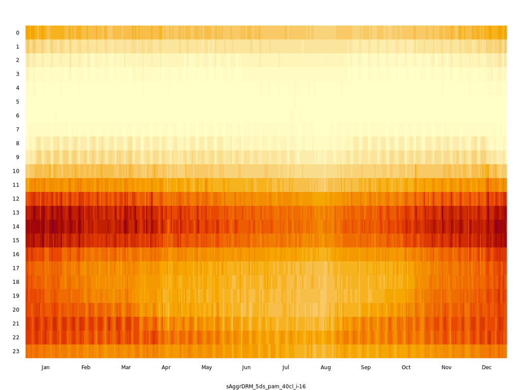

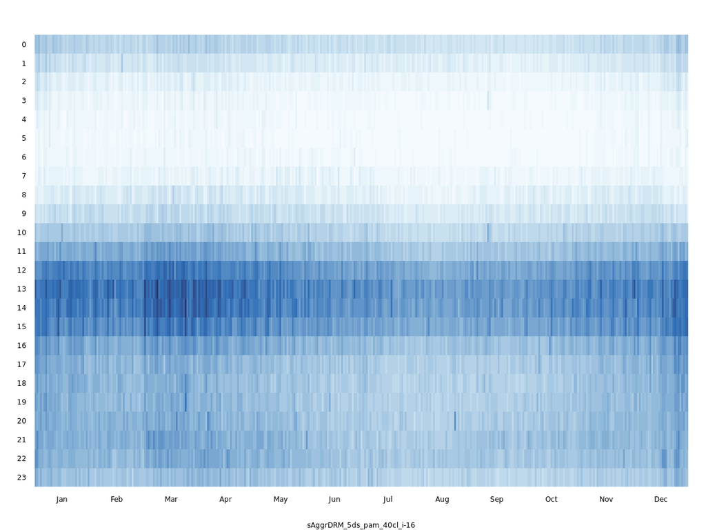

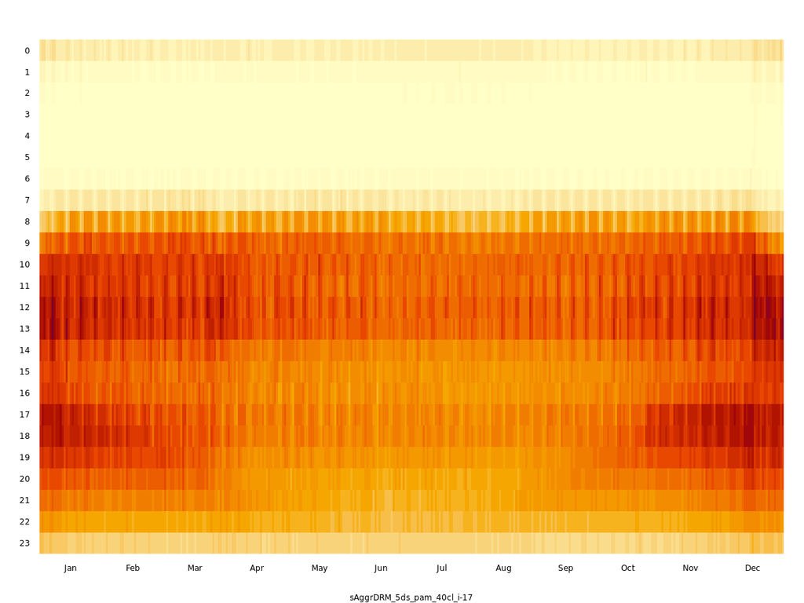

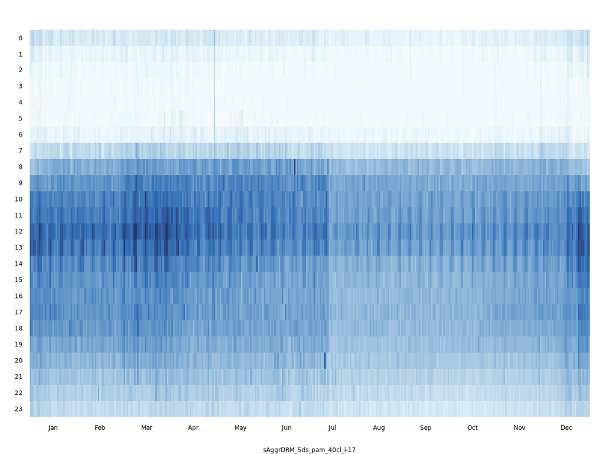

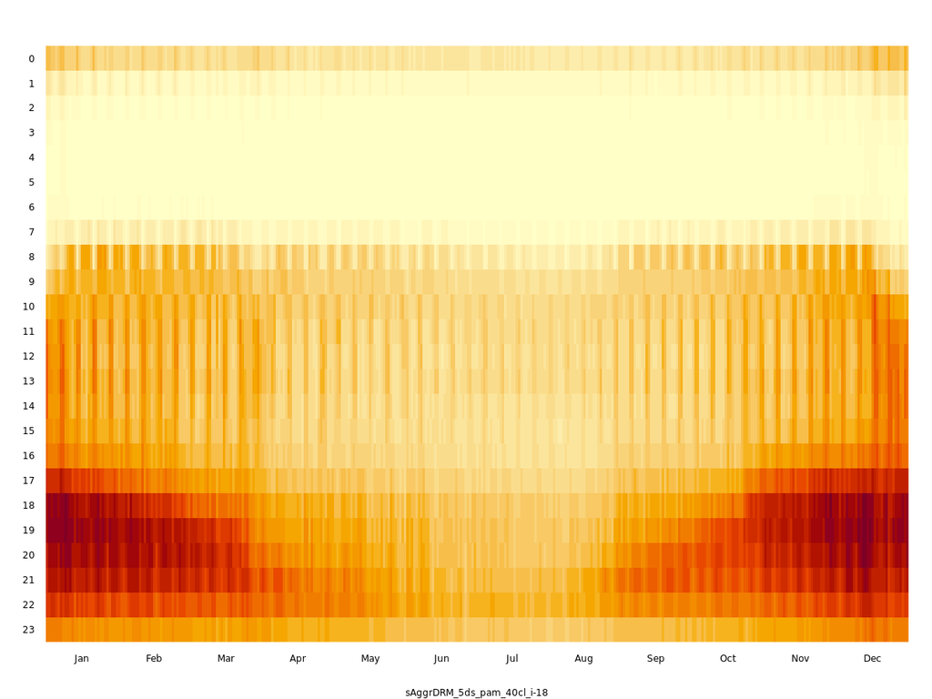

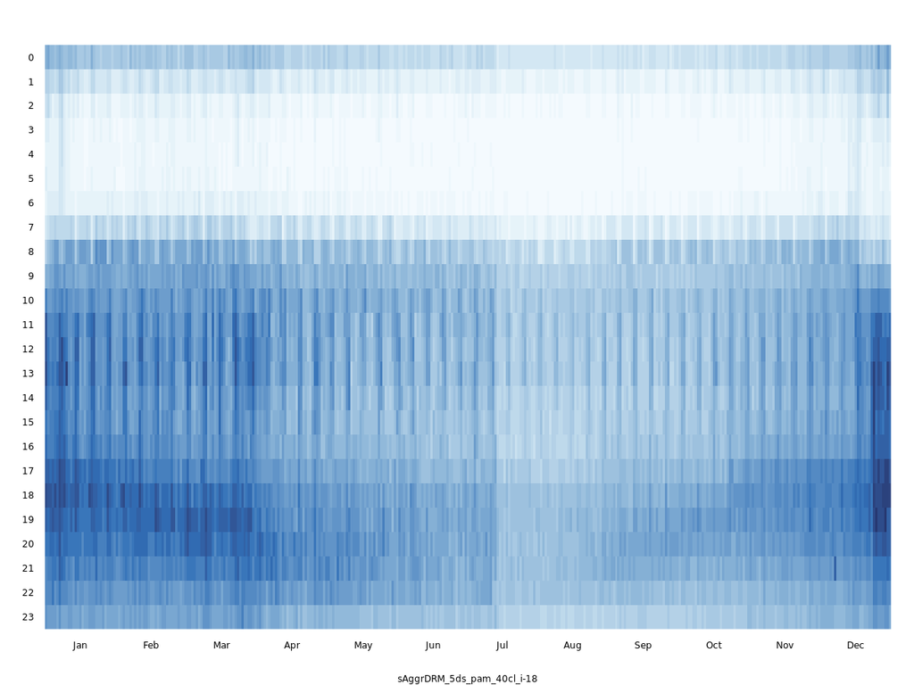

sAggrDRM > 5ds > pam > μ > #16

704 TS (2.9%)

sAggrDRM > 5ds > pam > σ > #16

704 TS (2.9%)

sAggrDRM > 5ds > pam > μ > #17

708 TS (3%)

sAggrDRM > 5ds > pam > σ > #17

708 TS (3%)

sAggrDRM > 5ds > pam > μ > #18

887 TS (3.7%)

sAggrDRM > 5ds > pam > σ > #18

887 TS (3.7%)

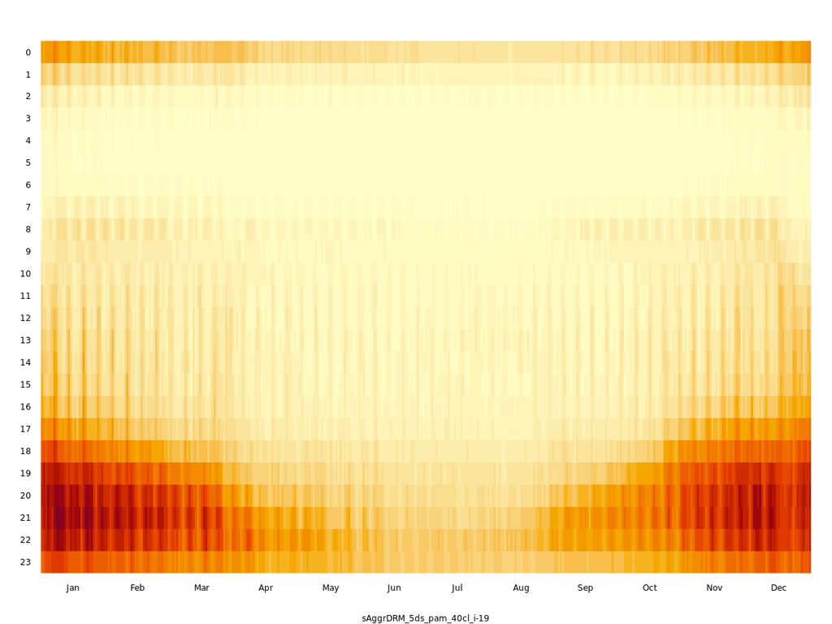

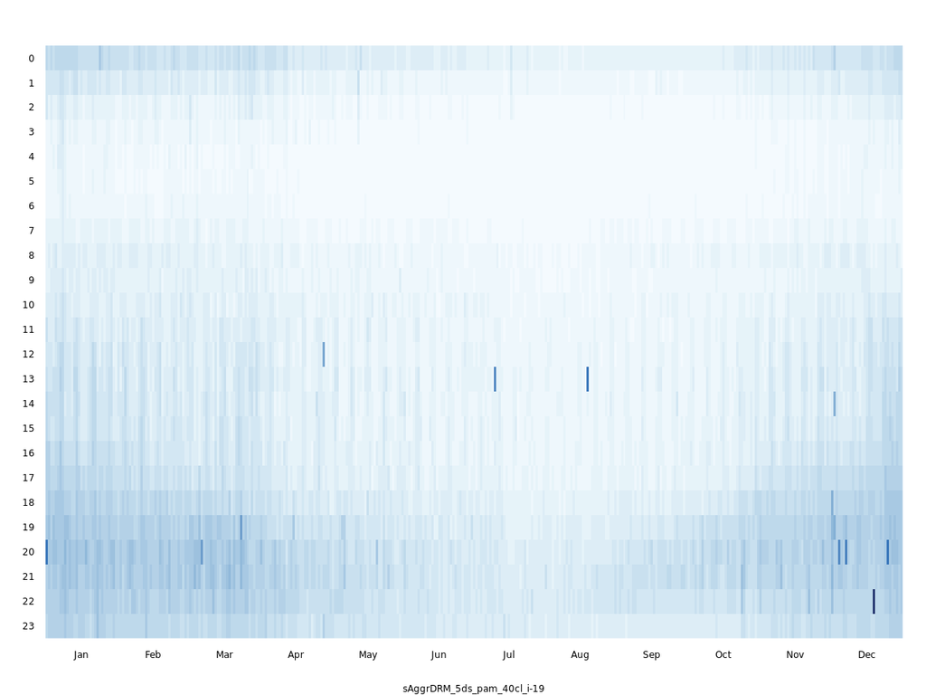

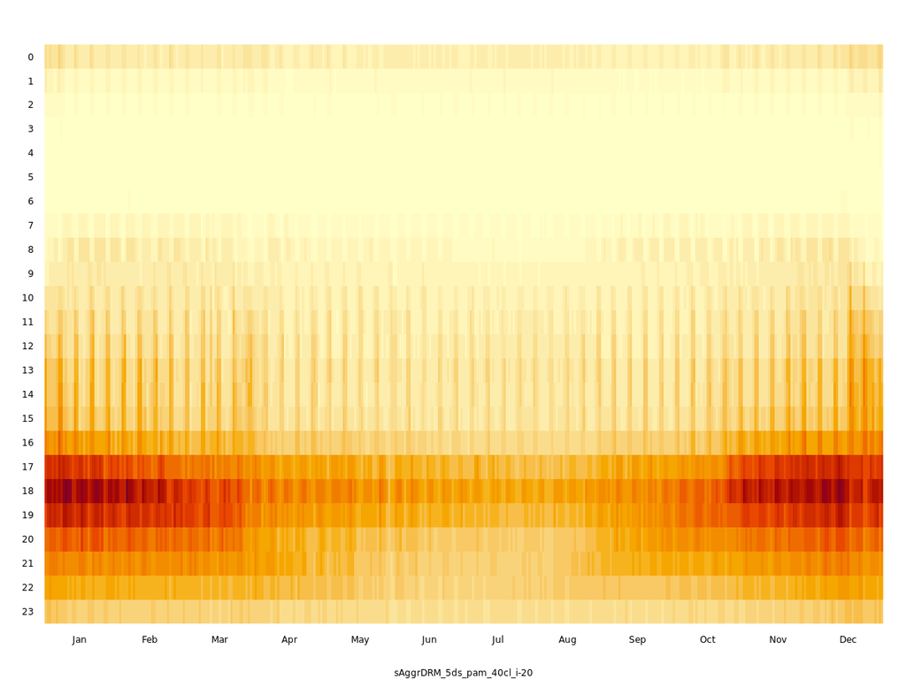

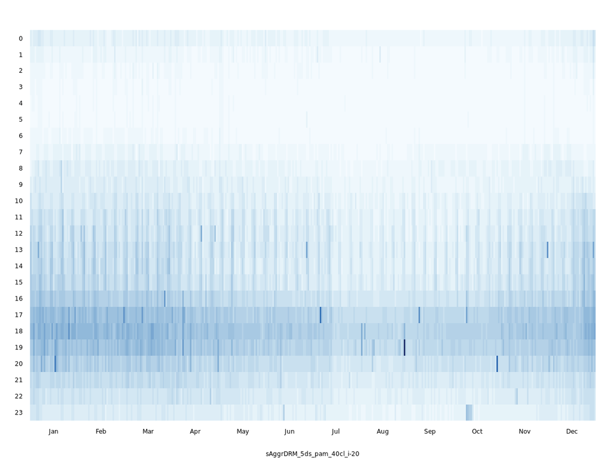

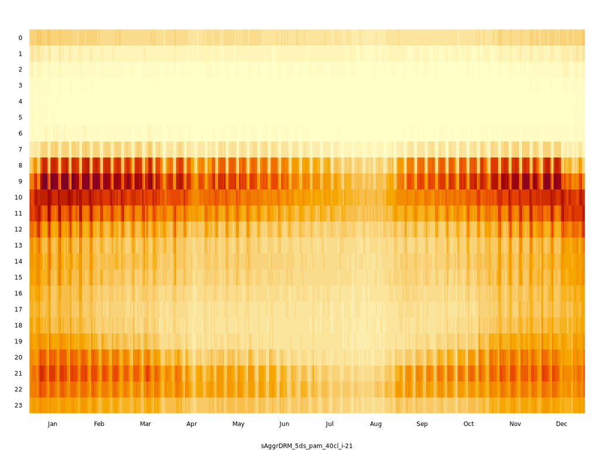

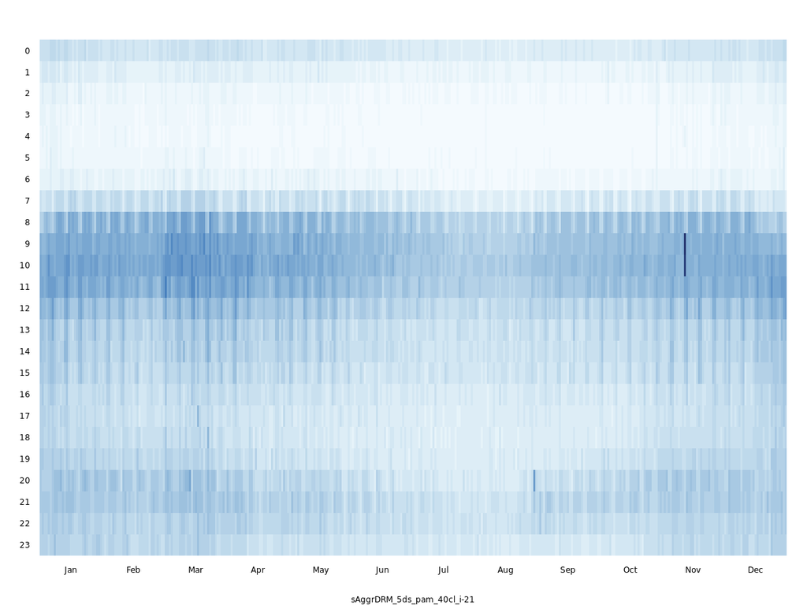

sAggrDRM > 5ds > pam > μ > #19

502 TS (2.1%)

sAggrDRM > 5ds > pam > σ > #19

502 TS (2.1%)

sAggrDRM > 5ds > pam > μ > #20

511 TS (2.1%)

sAggrDRM > 5ds > pam > σ > #20

511 TS (2.1%)

sAggrDRM > 5ds > pam > μ > #21

808 TS (3.4%)

sAggrDRM > 5ds > pam > σ > #21

808 TS (3.4%)

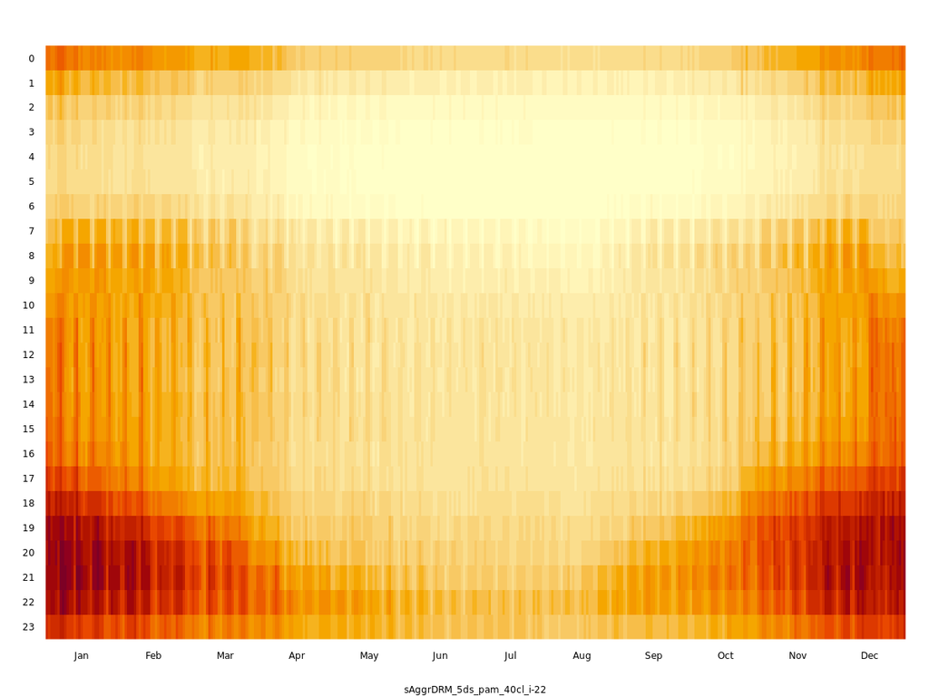

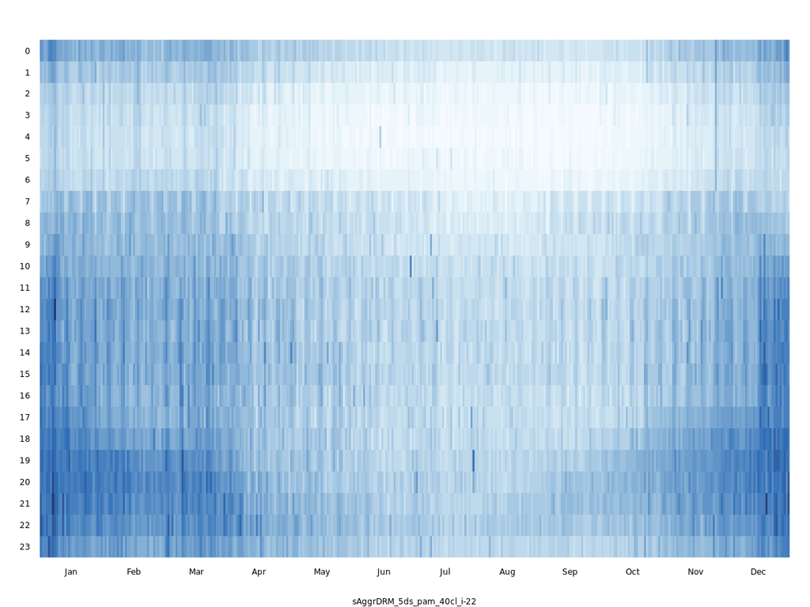

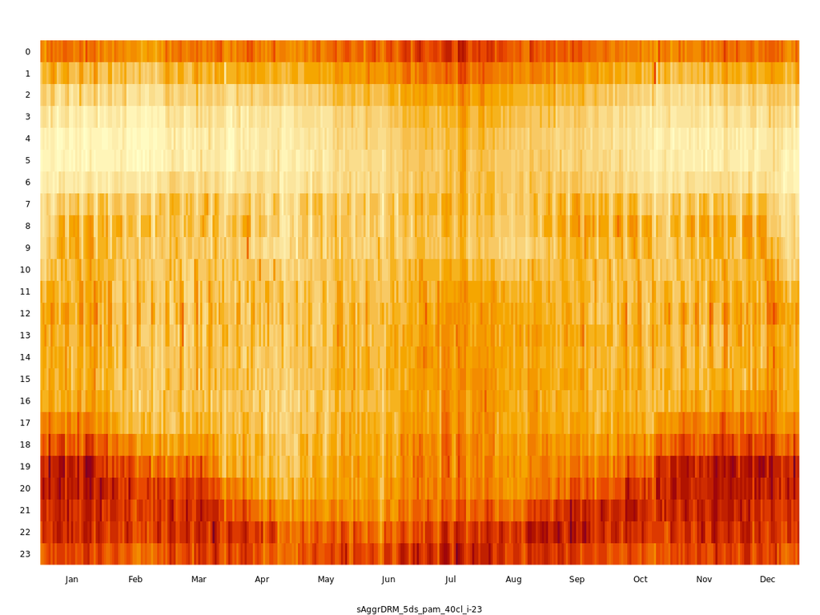

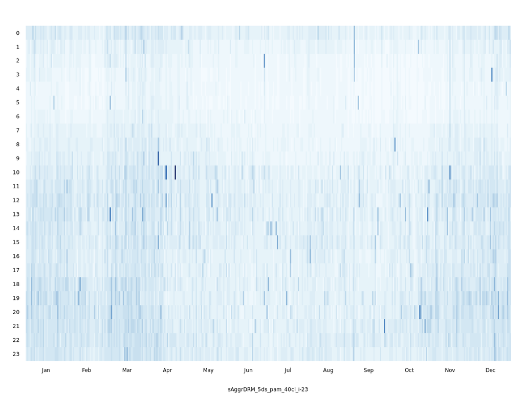

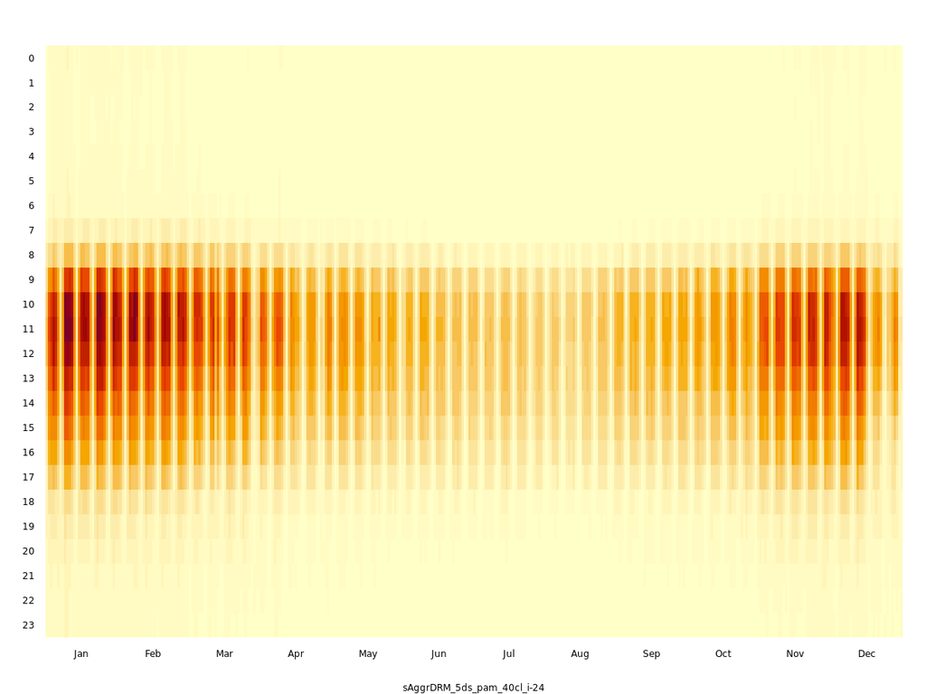

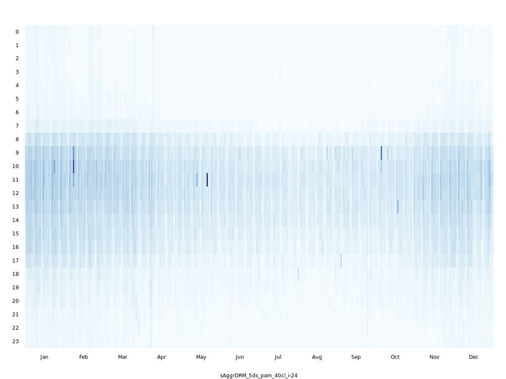

sAggrDRM > 5ds > pam > μ > #22

960 TS (4%)

sAggrDRM > 5ds > pam > σ > #22

960 TS (4%)

sAggrDRM > 5ds > pam > μ > #23

785 TS (3.3%)

sAggrDRM > 5ds > pam > σ > #23

785 TS (3.3%)

sAggrDRM > 5ds > pam > μ > #24

273 TS (1.1%)

sAggrDRM > 5ds > pam > σ > #24

273 TS (1.1%)

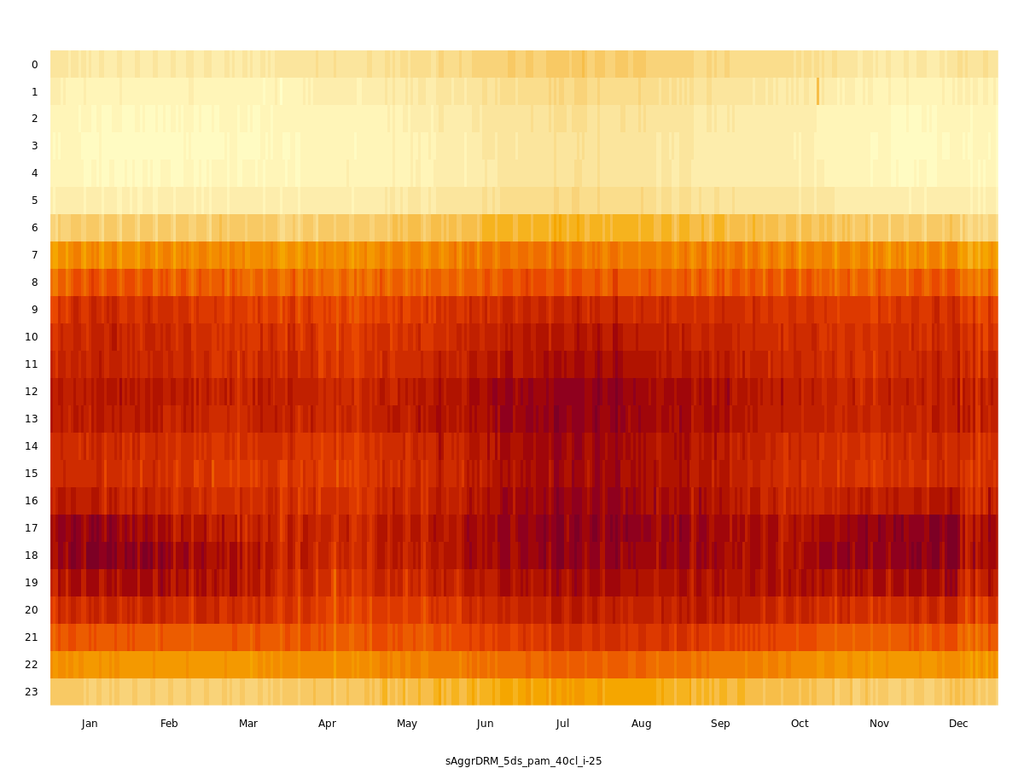

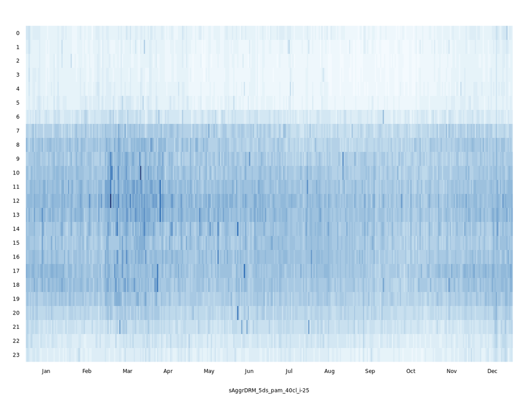

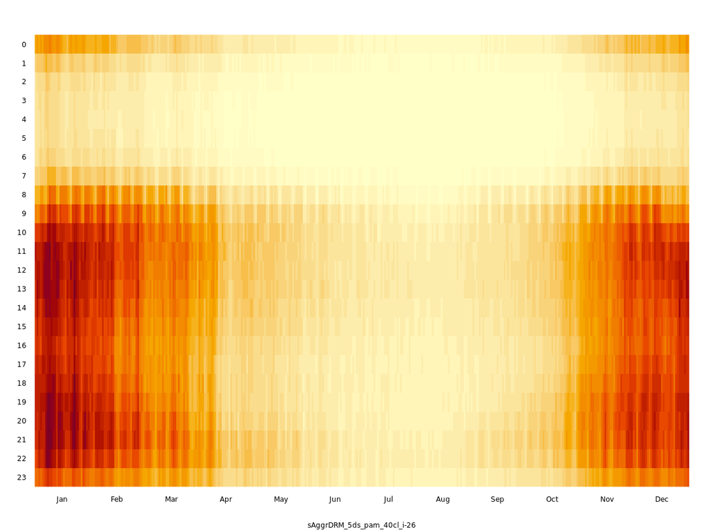

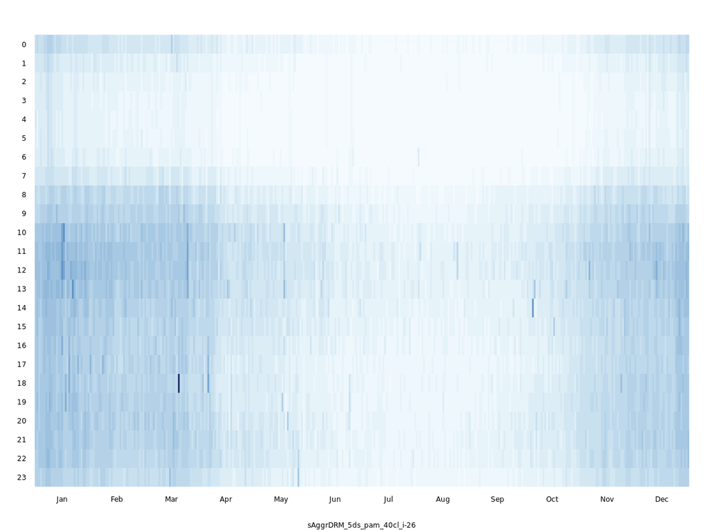

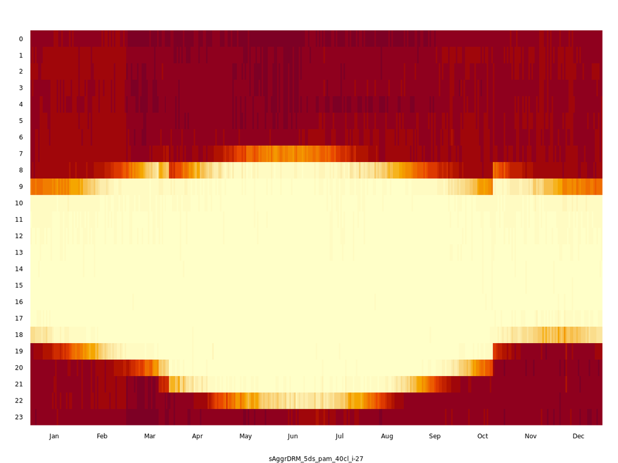

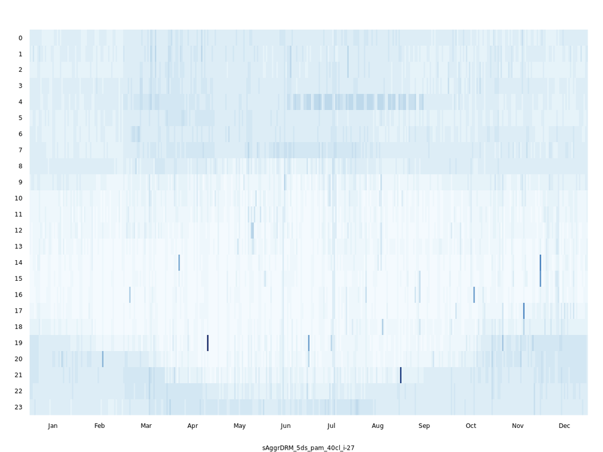

sAggrDRM > 5ds > pam > μ > #25

756 TS (3.2%)

sAggrDRM > 5ds > pam > σ > #25

756 TS (3.2%)

sAggrDRM > 5ds > pam > μ > #26

379 TS (1.6%)

sAggrDRM > 5ds > pam > σ > #26

379 TS (1.6%)

sAggrDRM > 5ds > pam > μ > #27

249 TS (1%)

sAggrDRM > 5ds > pam > σ > #27

249 TS (1%)

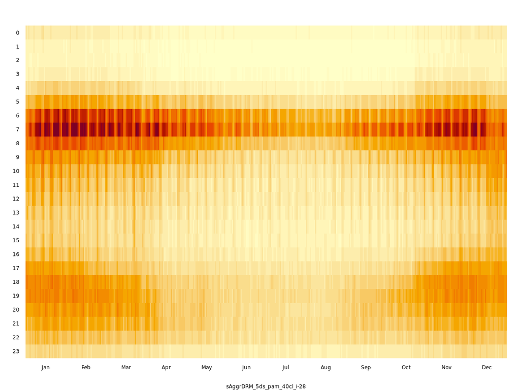

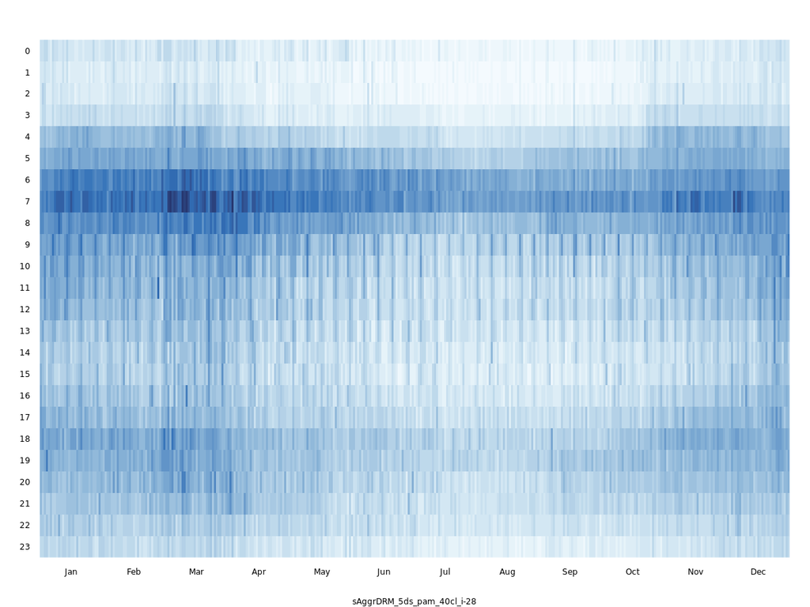

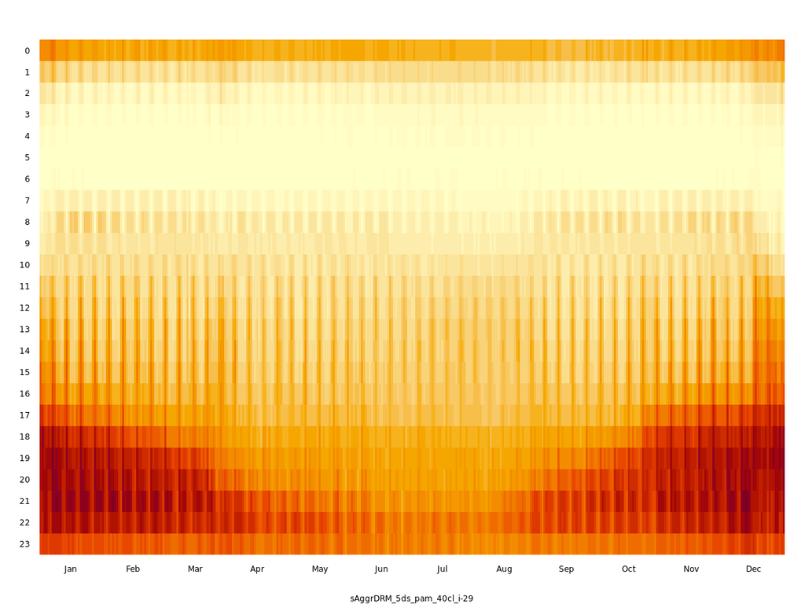

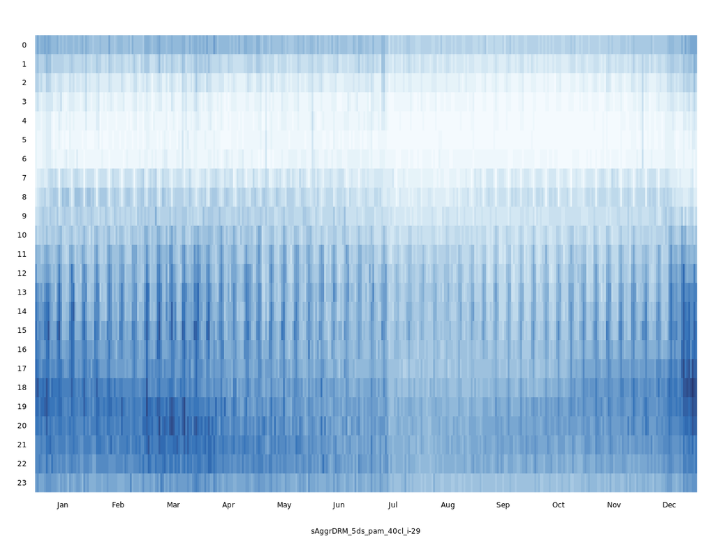

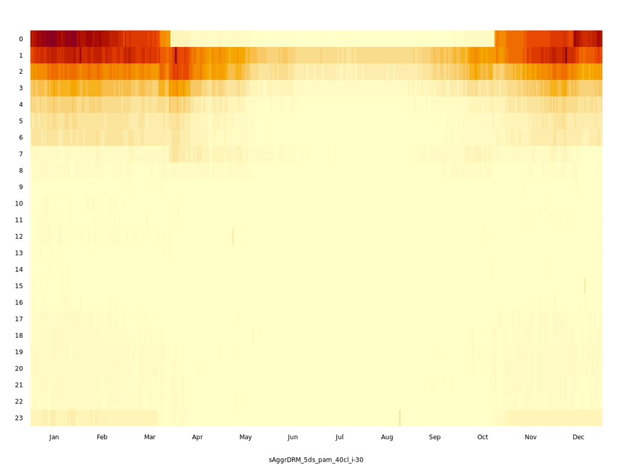

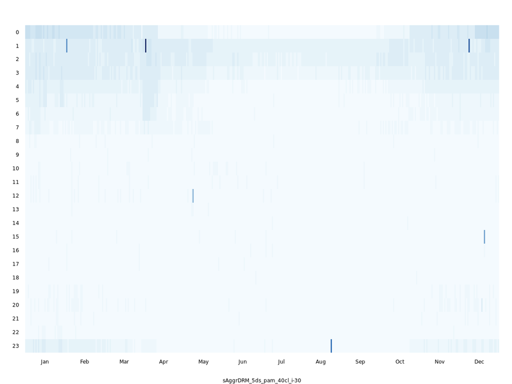

sAggrDRM > 5ds > pam > μ > #28

242 TS (1%)

sAggrDRM > 5ds > pam > σ > #28

242 TS (1%)

sAggrDRM > 5ds > pam > μ > #29

887 TS (3.7%)

sAggrDRM > 5ds > pam > σ > #29

887 TS (3.7%)

sAggrDRM > 5ds > pam > μ > #30

51 TS (0.2%)

sAggrDRM > 5ds > pam > σ > #30

51 TS (0.2%)

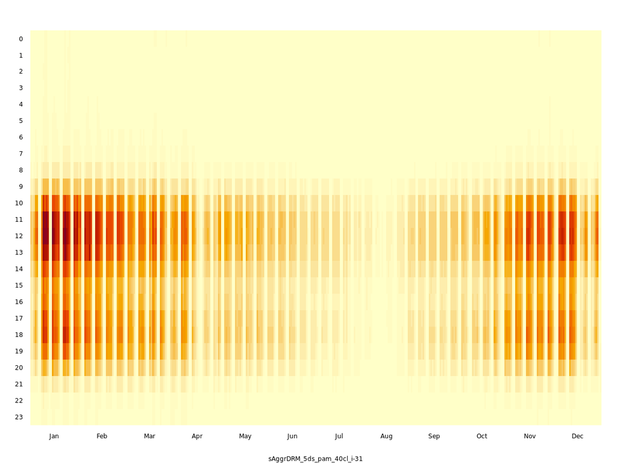

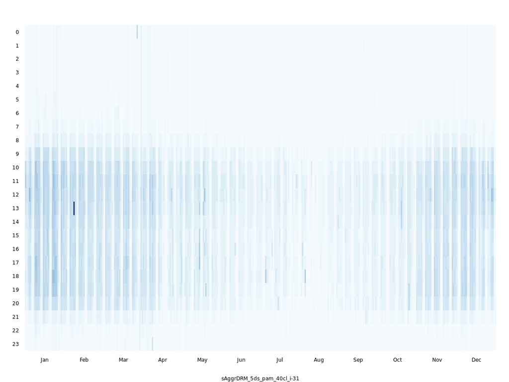

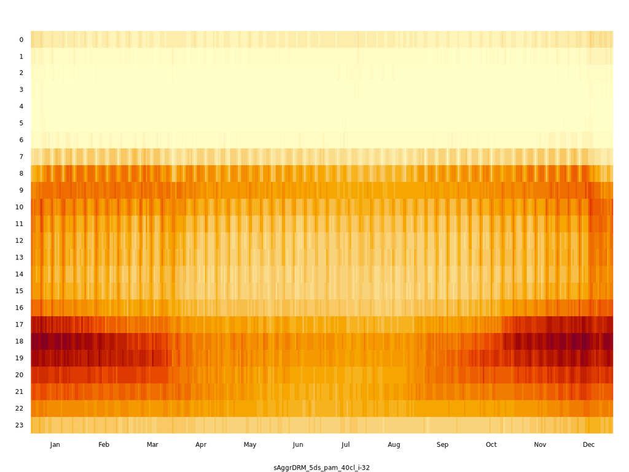

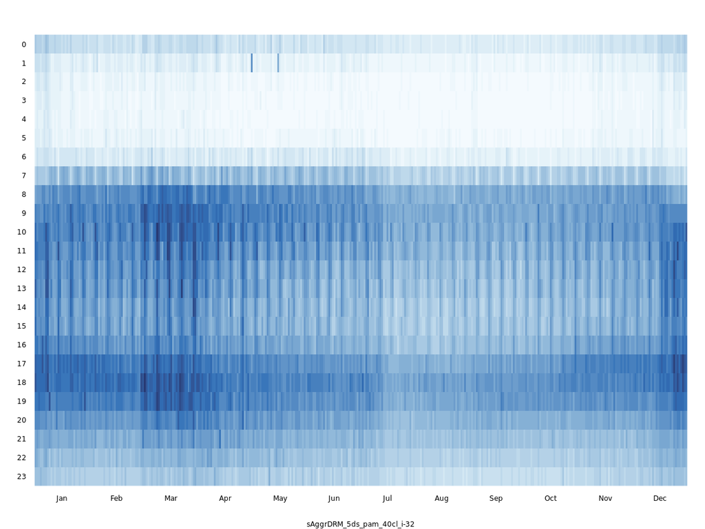

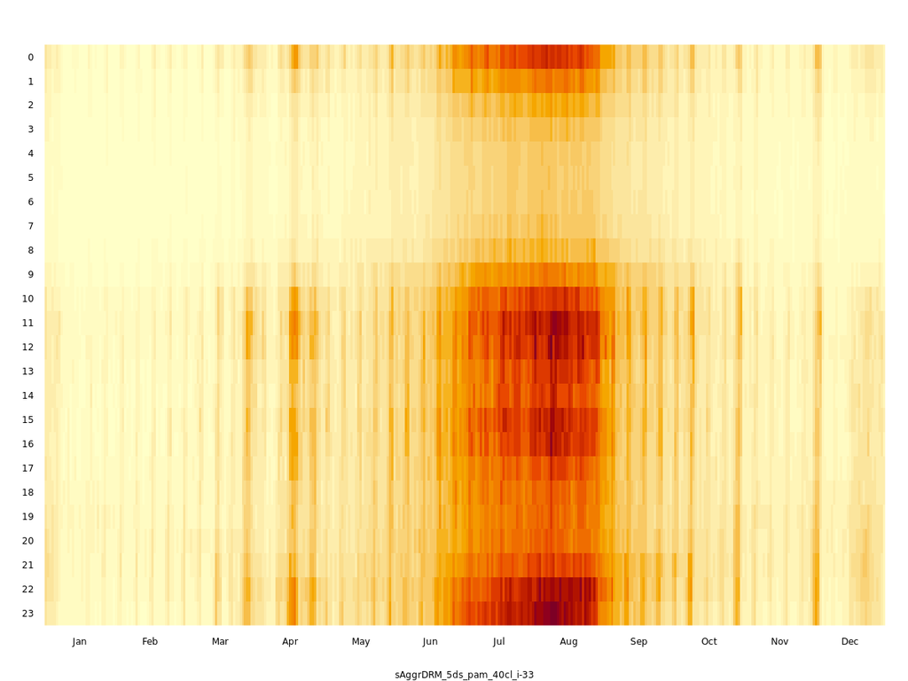

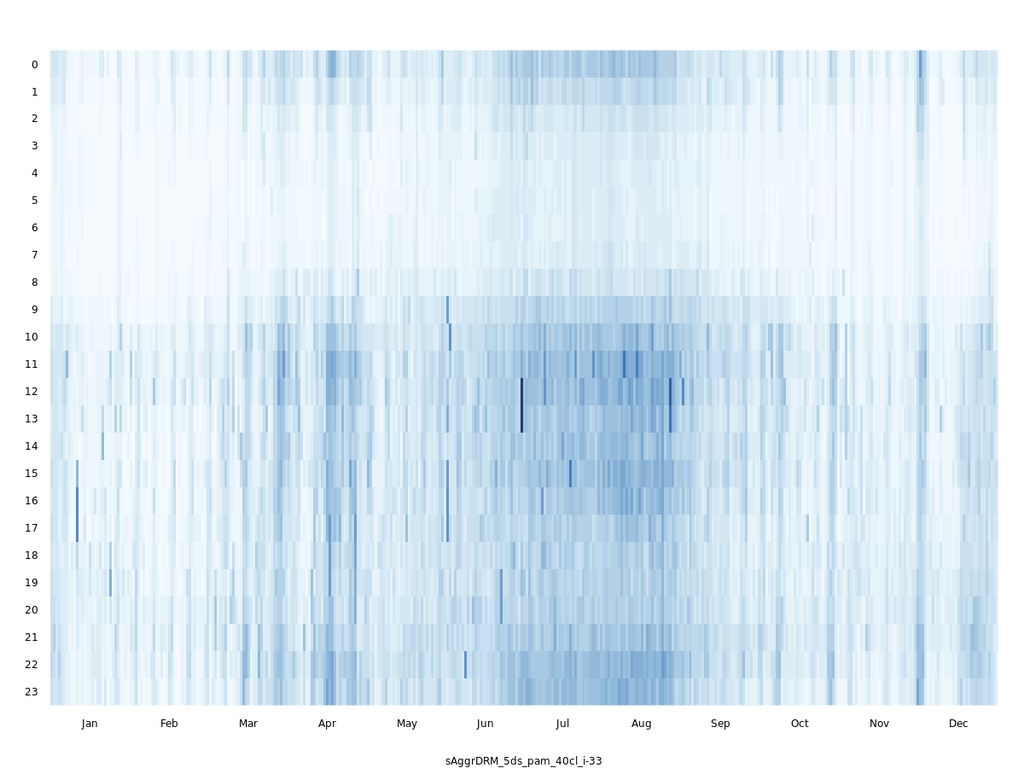

sAggrDRM > 5ds > pam > μ > #31

225 TS (0.9%)

sAggrDRM > 5ds > pam > σ > #31

225 TS (0.9%)

sAggrDRM > 5ds > pam > μ > #32

882 TS (3.7%)

sAggrDRM > 5ds > pam > σ > #32

882 TS (3.7%)

sAggrDRM > 5ds > pam > μ > #33

286 TS (1.2%)

sAggrDRM > 5ds > pam > σ > #33

286 TS (1.2%)

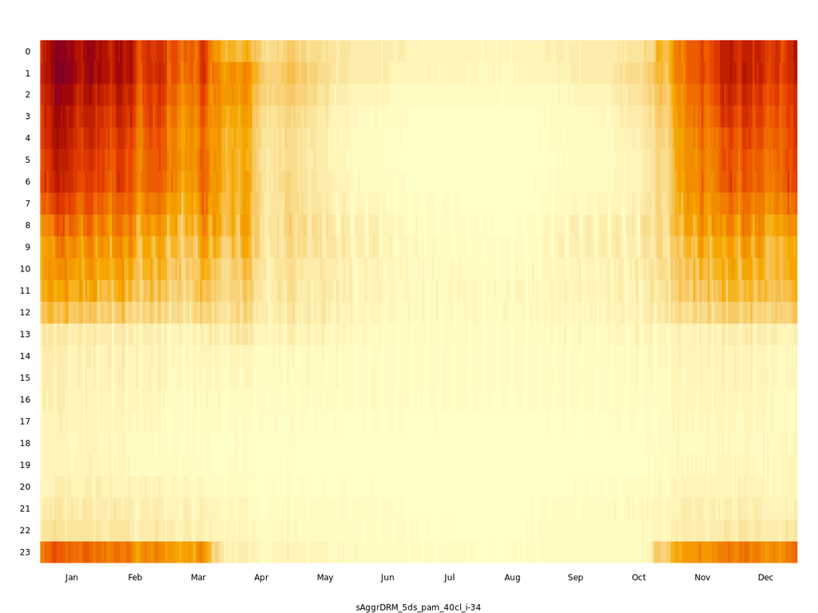

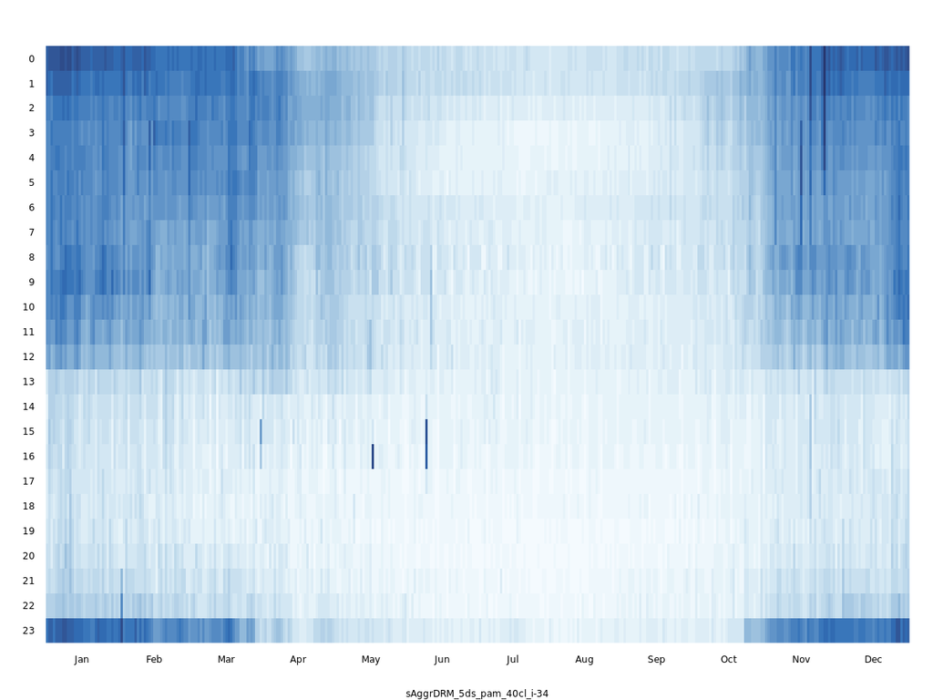

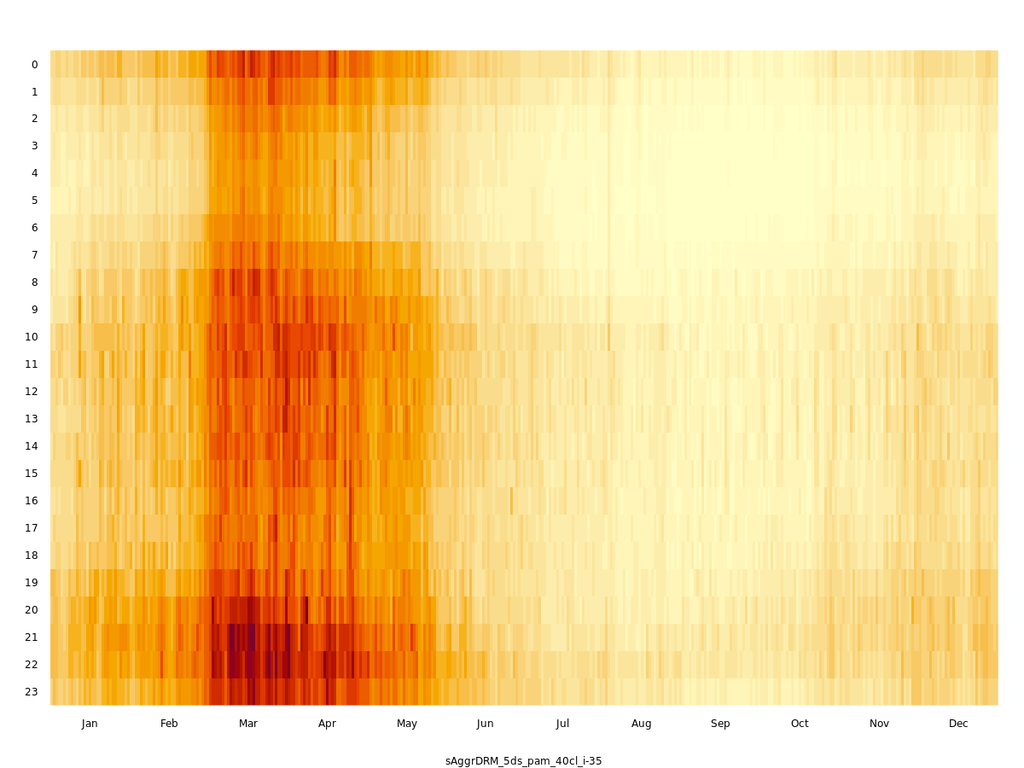

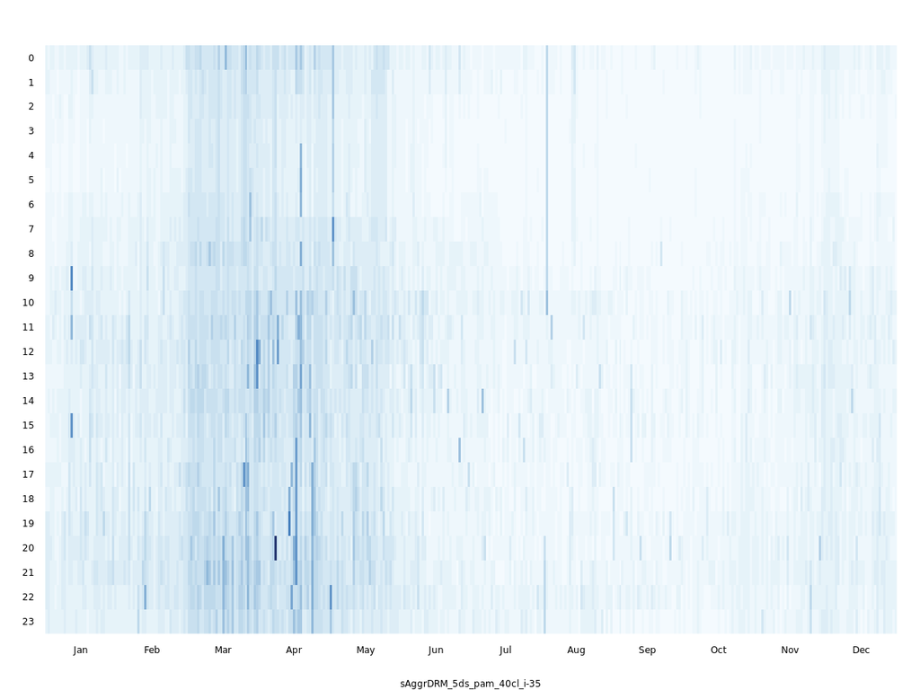

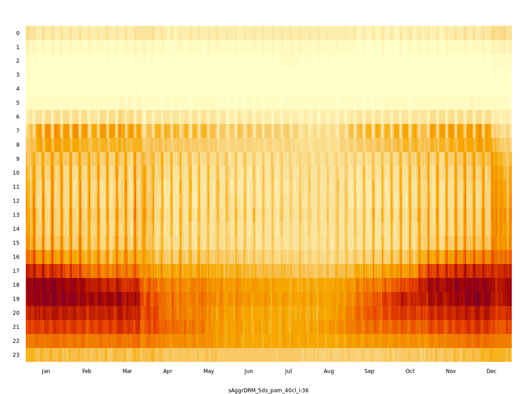

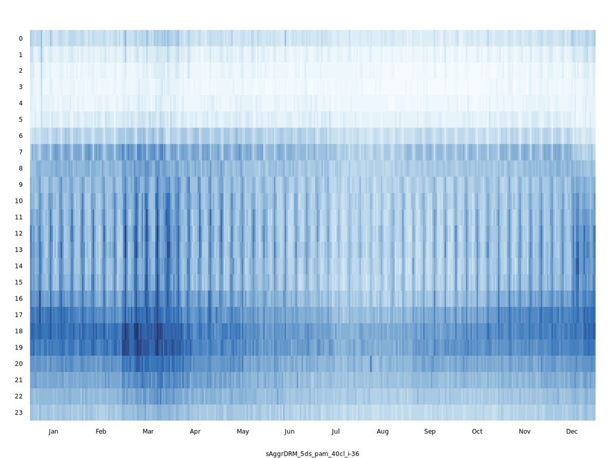

sAggrDRM > 5ds > pam > μ > #34

200 TS (0.8%)

sAggrDRM > 5ds > pam > σ > #34

200 TS (0.8%)

sAggrDRM > 5ds > pam > μ > #35

158 TS (0.7%)

sAggrDRM > 5ds > pam > σ > #35

158 TS (0.7%)

sAggrDRM > 5ds > pam > μ > #36

963 TS (4%)

sAggrDRM > 5ds > pam > σ > #36

963 TS (4%)

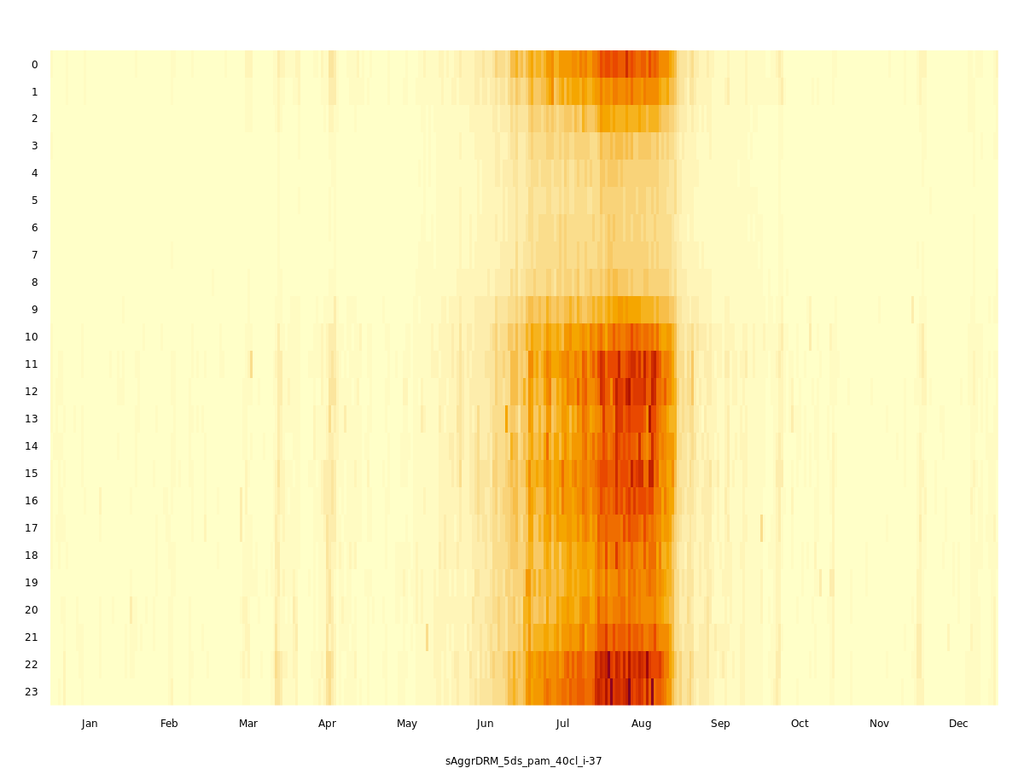

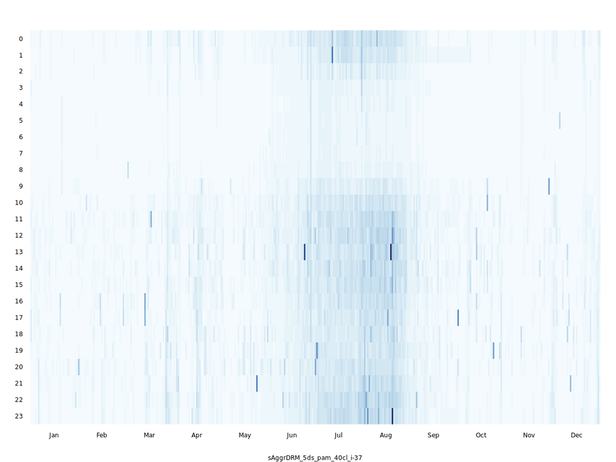

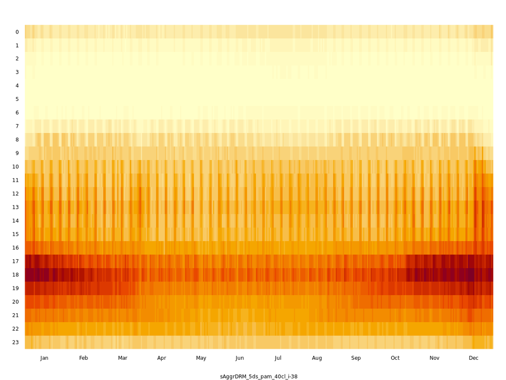

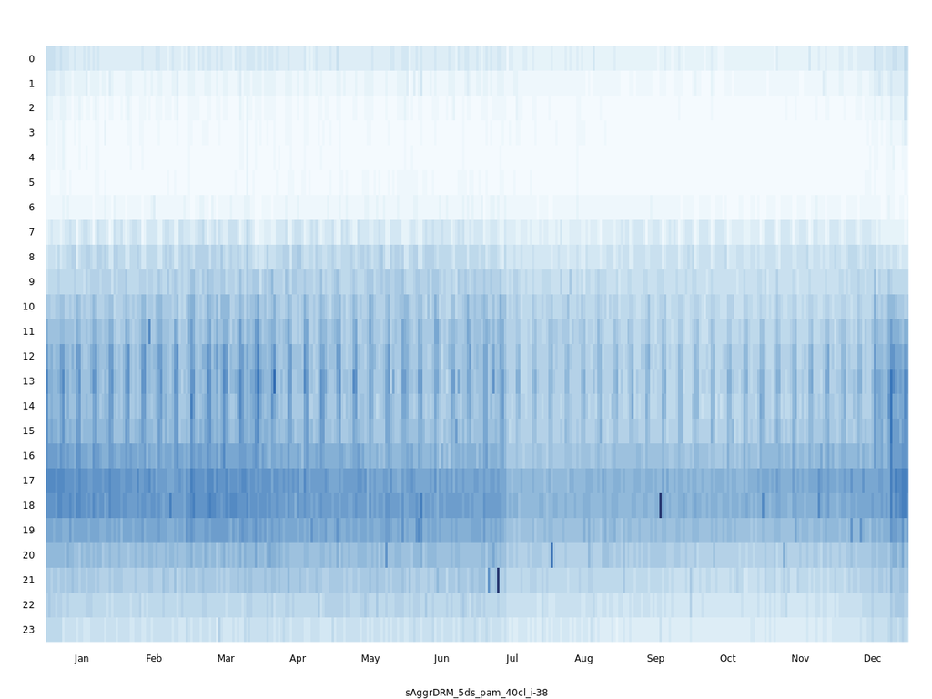

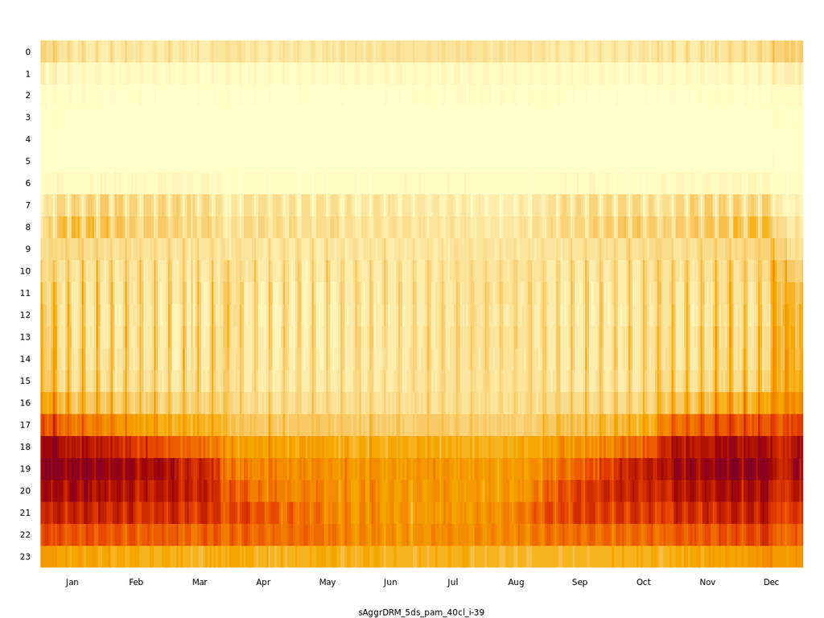

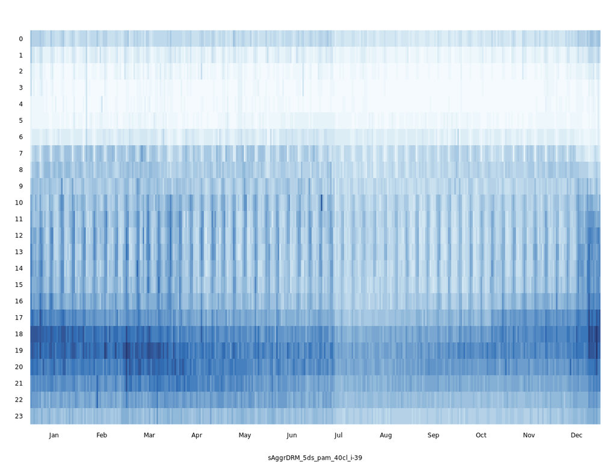

sAggrDRM > 5ds > pam > μ > #37

129 TS (0.5%)

sAggrDRM > 5ds > pam > σ > #37

129 TS (0.5%)

sAggrDRM > 5ds > pam > μ > #38

1039 TS (4.3%)

sAggrDRM > 5ds > pam > σ > #38

1039 TS (4.3%)

sAggrDRM > 5ds > pam > μ > #39

669 TS (2.8%)

sAggrDRM > 5ds > pam > σ > #39

669 TS (2.8%)

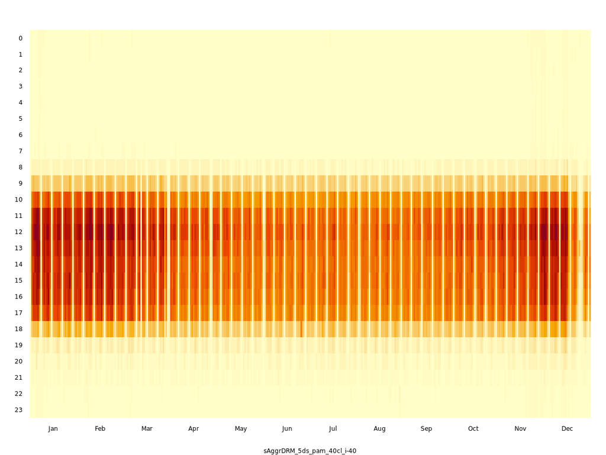

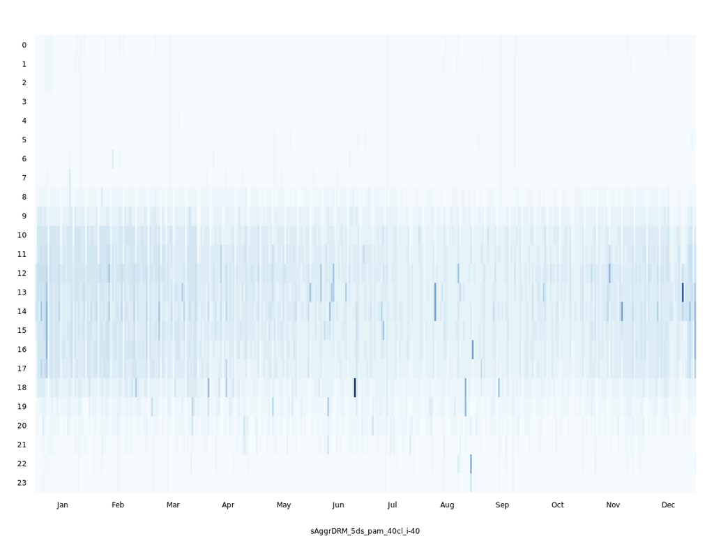

sAggrDRM > 5ds > pam > μ > #40

136 TS (0.6%)

sAggrDRM > 5ds > pam > σ > #40

136 TS (0.6%)